# Practical Machine Learning

Stefan Moser

September 2015

### Question

This is a course project of a MOOC in coursera called “Practical Machine Learning”. Large amount of data about personal activity has been provided to find patterns of individual health behaviours.

In this project, the target will be to use data from accelerometers on the belt, forearm, arm, and dumbell of 6 participants. They were asked to perform barbell lifts correctly and incorrectly in 5 different ways.

### Input Data

###### Preparing the data and R packages

```r
#Load packages
library(AppliedPredictiveModeling)
library(caret)
library(rattle)
library(rpart.plot)
library(randomForest)
```

##### The first step is to import the data and to verify that the training data and the test data are identical.

```r
#cleaning worksapace
rm(list = ls())

#set path
path <- "D:/Studio/Course"

#read csv training data
file_training <- "pml-training.csv"
df_training <- read.csv(file_training, na.strings=c("NA",""), header=TRUE)
colnames_train <- colnames(df_training)

#read csv testing data
file_testing <- "pml-testing.csv"
df_testing <- read.csv(file_testing, na.strings=c("NA",""), header=TRUE)
colnames_test <- colnames(df_testing)

#Verify that the column names (excluding classe and problem_id) are identical in the training and test set.
all.equal(colnames_train[1:length(colnames_train)-1], colnames_test[1:length(colnames_train)-1])
```

```
## [1] TRUE
```

### features

##### After I have ckecked the schema of both the training and testing sets are identical, I decided to delet NA columns and other extraneous columns.

```r
# Count the number of non-NAs in each col.
nonNAs <- function(x) {
  as.vector(apply(x, 2, function(x) length(which(!is.na(x)))))
}

# Build vector of missing data or NA columns to drop.
colcnts <- nonNAs(df_training)
drops <- c()
for (cnt in 1:length(colcnts)) {
  if (colcnts[cnt] < nrow(df_training)) {
    drops <- c(drops, colnames_train[cnt])
  }
}

# Drop NA data and the first 7 columns as they're unnecessary for predicting.
df_training <- df_training[,!(names(df_training) %in% drops)]
df_training <- df_training[,8:length(colnames(df_training))]

df_testing <- df_testing[,!(names(df_testing) %in% drops)]
df_testing <- df_testing[,8:length(colnames(df_testing))]

# check if values without variance
nzv <- nearZeroVar(df_training , saveMetrics= TRUE)
nzv
```

```
##                      freqRatio percentUnique zeroVar   nzv
## roll_belt             1.101904     6.7781062   FALSE FALSE
## pitch_belt            1.036082     9.3772296   FALSE FALSE
## yaw_belt              1.058480     9.9734991   FALSE FALSE
## total_accel_belt      1.063160     0.1477933   FALSE FALSE
## gyros_belt_x          1.058651     0.7134849   FALSE FALSE
## gyros_belt_y          1.144000     0.3516461   FALSE FALSE
## gyros_belt_z          1.066214     0.8612782   FALSE FALSE
## accel_belt_x          1.055412     0.8357966   FALSE FALSE
## accel_belt_y          1.113725     0.7287738   FALSE FALSE
## accel_belt_z          1.078767     1.5237998   FALSE FALSE
## magnet_belt_x         1.090141     1.6664968   FALSE FALSE
## magnet_belt_y         1.099688     1.5187035   FALSE FALSE
## magnet_belt_z         1.006369     2.3290184   FALSE FALSE
## roll_arm             52.338462    13.5256345   FALSE FALSE
## pitch_arm            87.256410    15.7323412   FALSE FALSE
## yaw_arm              33.029126    14.6570176   FALSE FALSE
## total_accel_arm       1.024526     0.3363572   FALSE FALSE
## gyros_arm_x           1.015504     3.2769341   FALSE FALSE
## gyros_arm_y           1.454369     1.9162165   FALSE FALSE
## gyros_arm_z           1.110687     1.2638875   FALSE FALSE
## accel_arm_x           1.017341     3.9598410   FALSE FALSE
## accel_arm_y           1.140187     2.7367241   FALSE FALSE
## accel_arm_z           1.128000     4.0362858   FALSE FALSE
## magnet_arm_x          1.000000     6.8239731   FALSE FALSE
## magnet_arm_y          1.056818     4.4439914   FALSE FALSE
## magnet_arm_z          1.036364     6.4468454   FALSE FALSE
## roll_dumbbell         1.022388    84.2065029   FALSE FALSE
## pitch_dumbbell        2.277372    81.7449801   FALSE FALSE
## yaw_dumbbell          1.132231    83.4828254   FALSE FALSE
## total_accel_dumbbell  1.072634     0.2191418   FALSE FALSE
## gyros_dumbbell_x      1.003268     1.2282132   FALSE FALSE
## gyros_dumbbell_y      1.264957     1.4167771   FALSE FALSE
## gyros_dumbbell_z      1.060100     1.0498420   FALSE FALSE
## accel_dumbbell_x      1.018018     2.1659362   FALSE FALSE
## accel_dumbbell_y      1.053061     2.3748853   FALSE FALSE
## accel_dumbbell_z      1.133333     2.0894914   FALSE FALSE
## magnet_dumbbell_x     1.098266     5.7486495   FALSE FALSE
## magnet_dumbbell_y     1.197740     4.3012945   FALSE FALSE
## magnet_dumbbell_z     1.020833     3.4451126   FALSE FALSE
## roll_forearm         11.589286    11.0895933   FALSE FALSE
## pitch_forearm        65.983051    14.8557741   FALSE FALSE
## yaw_forearm          15.322835    10.1467740   FALSE FALSE
## total_accel_forearm   1.128928     0.3567424   FALSE FALSE
## gyros_forearm_x       1.059273     1.5187035   FALSE FALSE
## gyros_forearm_y       1.036554     3.7763735   FALSE FALSE
## gyros_forearm_z       1.122917     1.5645704   FALSE FALSE
## accel_forearm_x       1.126437     4.0464784   FALSE FALSE
## accel_forearm_y       1.059406     5.1116094   FALSE FALSE
## accel_forearm_z       1.006250     2.9558659   FALSE FALSE
## magnet_forearm_x      1.012346     7.7667924   FALSE FALSE
## magnet_forearm_y      1.246914     9.5403119   FALSE FALSE
## magnet_forearm_z      1.000000     8.5771073   FALSE FALSE
## classe                1.469581     0.0254816   FALSE FALSE
```

```r
# Show remaining columns.
colnames(df_training)
```

```
##  [1] "roll_belt"            "pitch_belt"           "yaw_belt"
##  [4] "total_accel_belt"     "gyros_belt_x"         "gyros_belt_y"
##  [7] "gyros_belt_z"         "accel_belt_x"         "accel_belt_y"
## [10] "accel_belt_z"         "magnet_belt_x"        "magnet_belt_y"
## [13] "magnet_belt_z"        "roll_arm"             "pitch_arm"
## [16] "yaw_arm"              "total_accel_arm"      "gyros_arm_x"
## [19] "gyros_arm_y"          "gyros_arm_z"          "accel_arm_x"
## [22] "accel_arm_y"          "accel_arm_z"          "magnet_arm_x"
## [25] "magnet_arm_y"         "magnet_arm_z"         "roll_dumbbell"
## [28] "pitch_dumbbell"       "yaw_dumbbell"         "total_accel_dumbbell"
## [31] "gyros_dumbbell_x"     "gyros_dumbbell_y"     "gyros_dumbbell_z"
## [34] "accel_dumbbell_x"     "accel_dumbbell_y"     "accel_dumbbell_z"
## [37] "magnet_dumbbell_x"    "magnet_dumbbell_y"    "magnet_dumbbell_z"
## [40] "roll_forearm"         "pitch_forearm"        "yaw_forearm"
## [43] "total_accel_forearm"  "gyros_forearm_x"      "gyros_forearm_y"
## [46] "gyros_forearm_z"      "accel_forearm_x"      "accel_forearm_y"
## [49] "accel_forearm_z"      "magnet_forearm_x"     "magnet_forearm_y"
## [52] "magnet_forearm_z"     "classe"
```

```r
# Show remaining columns.
colnames(df_testing)
```

```
##  [1] "roll_belt"            "pitch_belt"           "yaw_belt"
##  [4] "total_accel_belt"     "gyros_belt_x"         "gyros_belt_y"
##  [7] "gyros_belt_z"         "accel_belt_x"         "accel_belt_y"
## [10] "accel_belt_z"         "magnet_belt_x"        "magnet_belt_y"
## [13] "magnet_belt_z"        "roll_arm"             "pitch_arm"
## [16] "yaw_arm"              "total_accel_arm"      "gyros_arm_x"
## [19] "gyros_arm_y"          "gyros_arm_z"          "accel_arm_x"
## [22] "accel_arm_y"          "accel_arm_z"          "magnet_arm_x"
## [25] "magnet_arm_y"         "magnet_arm_z"         "roll_dumbbell"
## [28] "pitch_dumbbell"       "yaw_dumbbell"         "total_accel_dumbbell"
## [31] "gyros_dumbbell_x"     "gyros_dumbbell_y"     "gyros_dumbbell_z"
## [34] "accel_dumbbell_x"     "accel_dumbbell_y"     "accel_dumbbell_z"
## [37] "magnet_dumbbell_x"    "magnet_dumbbell_y"    "magnet_dumbbell_z"
## [40] "roll_forearm"         "pitch_forearm"        "yaw_forearm"
## [43] "total_accel_forearm"  "gyros_forearm_x"      "gyros_forearm_y"
## [46] "gyros_forearm_z"      "accel_forearm_x"      "accel_forearm_y"
## [49] "accel_forearm_z"      "magnet_forearm_x"     "magnet_forearm_y"
## [52] "magnet_forearm_z"     "problem_id"
```

### algorithm

```r
#Now we have  a large training set (19,622 entries) and a small testing set (20 entries). I decided to split the training set into a df_pretraining set (40%) and a df_pretesting set (60%). I decided this approach, because the later choosen algorithm will work faster and I can test the algorithm with my pre_testing set

# Divide the given training set into parts
set.seed(1000)
inTrain <- createDataPartition(y=df_training$classe, p=0.4, list=FALSE)
df_pretraining <- df_training[inTrain,]
df_pretesting <- df_training[-inTrain,]
```

### parameters

##### I decided to try the methods preprocessing and cross validation. In my first test I have noticed, that this methods only have an accuracy smaller 0.6.

##### The result is too bad, so I attempt random forest with cross validation. You can see the results in the evaluation part

### evaluation

```r
# Check correlations
chkCor <- abs(cor(df_training[,-c(ncol(df_training))]))
diag(chkCor) <- 0
which(chkCor > 0.95,arr.ind=T)
```

```
##                  row col
## total_accel_belt   4   1
## accel_belt_z      10   1
## accel_belt_x       8   2
## roll_belt          1   4
## accel_belt_z      10   4
## pitch_belt         2   8
## roll_belt          1  10
## total_accel_belt   4  10
## gyros_dumbbell_z  33  31
## gyros_dumbbell_x  31  33
```

```r
# Train on pretraining Data
set.seed(1000)
modFit <- train(df_pretraining$classe ~ ., data = df_pretraining, method="rpart")
print(modFit, digits=3)
```

```
## CART
##
## 7850 samples
##   52 predictor
##    5 classes: 'A', 'B', 'C', 'D', 'E'
##
## No pre-processing
## Resampling: Bootstrapped (25 reps)
## Summary of sample sizes: 7850, 7850, 7850, 7850, 7850, 7850, ...
## Resampling results across tuning parameters:
##
##   cp      Accuracy  Kappa   Accuracy SD  Kappa SD
##   0.0272  0.568     0.4509  0.0386       0.0542
##   0.0435  0.471     0.3039  0.0652       0.1091
##   0.1148  0.311     0.0385  0.0367       0.0573
##
## Accuracy was used to select the optimal model using  the largest value.
## The final value used for the model was cp = 0.0272.
```

```r
print(modFit$finalModel, digits=3)
```

```
## n= 7850
##
## node), split, n, loss, yval, (yprob)
##       * denotes terminal node
##
##   1) root 7850 5620 A (0.28 0.19 0.17 0.16 0.18)
##     2) roll_belt< 130 7195 4970 A (0.31 0.21 0.19 0.18 0.11)
##       4) pitch_forearm< -34 644    5 A (0.99 0.0078 0 0 0) *
##       5) pitch_forearm>=-34 6551 4960 A (0.24 0.23 0.21 0.2 0.12)
##        10) yaw_belt>=170 338   37 A (0.89 0.038 0 0.062 0.0089) *
##        11) yaw_belt< 170 6213 4710 B (0.21 0.24 0.22 0.2 0.13)
##          22) magnet_dumbbell_z< -93.5 755  303 A (0.6 0.28 0.034 0.065 0.024) *
##          23) magnet_dumbbell_z>=-93.5 5458 4120 C (0.15 0.24 0.25 0.22 0.14)
##            46) pitch_belt< -43 316   51 B (0.0095 0.84 0.092 0.025 0.035) *
##            47) pitch_belt>=-43 5142 3830 C (0.16 0.2 0.26 0.24 0.15)
##              94) magnet_dumbbell_x>=-446 2213 1540 B (0.17 0.31 0.09 0.25 0.19)
##               188) roll_belt< 118 1360  762 B (0.16 0.44 0.026 0.13 0.25) *
##               189) roll_belt>=118 853  488 D (0.2 0.094 0.19 0.43 0.09) *
##              95) magnet_dumbbell_x< -446 2929 1810 C (0.15 0.12 0.38 0.23 0.12) *
##     3) roll_belt>=130 655    5 E (0.0076 0 0 0 0.99) *
```

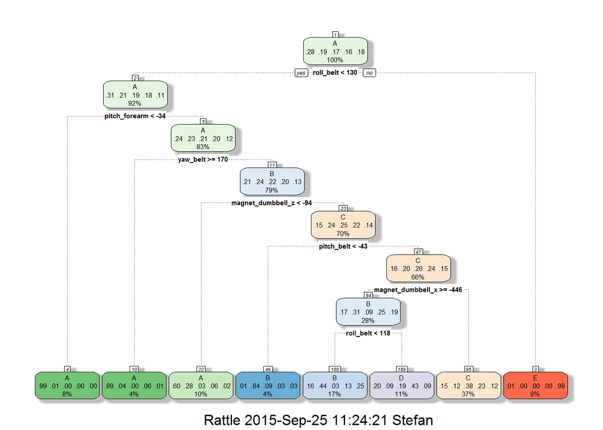

```r
fancyRpartPlot(modFit$finalModel)
```

```r
# Train on pretraining only preprocessing.
set.seed(1000)
modFit <- train(df_pretraining$classe ~ .,  preProcess=c("center", "scale"), data = df_pretraining, method="rpart")
print(modFit, digits=3)
```

```
## CART
##
## 7850 samples
##   52 predictor
##    5 classes: 'A', 'B', 'C', 'D', 'E'
##
## Pre-processing: centered, scaled
## Resampling: Bootstrapped (25 reps)
## Summary of sample sizes: 7850, 7850, 7850, 7850, 7850, 7850, ...
## Resampling results across tuning parameters:
##
##   cp      Accuracy  Kappa   Accuracy SD  Kappa SD
##   0.0272  0.568     0.4509  0.0386       0.0542
##   0.0435  0.471     0.3039  0.0652       0.1091
##   0.1148  0.311     0.0385  0.0367       0.0573
##
## Accuracy was used to select the optimal model using  the largest value.
## The final value used for the model was cp = 0.0272.
```

```r
# Train on pretraining set both preprocessing and cross validation.
set.seed(1000)
modFit <- train(df_pretraining$classe ~ .,  preProcess=c("center", "scale"), trControl=trainControl(method = "cv", number = 5), data = df_pretraining, method="rpart")
print(modFit, digits=3)
```

```
## CART
##
## 7850 samples
##   52 predictor
##    5 classes: 'A', 'B', 'C', 'D', 'E'
##
## Pre-processing: centered, scaled
## Resampling: Cross-Validated (5 fold)
## Summary of sample sizes: 6281, 6279, 6279, 6280, 6281
## Resampling results across tuning parameters:
##
##   cp      Accuracy  Kappa   Accuracy SD  Kappa SD
##   0.0272  0.573     0.4546  0.0363       0.0537
##   0.0435  0.476     0.3170  0.0666       0.1156
##   0.1148  0.349     0.0981  0.0358       0.0549
##
## Accuracy was used to select the optimal model using  the largest value.
## The final value used for the model was cp = 0.0272.
```

```r
# Run against pretesting set with both preprocessing and cross validation.
predictions <- predict(modFit, newdata=df_pretesting)
print(confusionMatrix(predictions, df_pretesting$classe), digits=4)
```

```
## Confusion Matrix and Statistics
##
##           Reference
## Prediction    A    B    C    D    E
##          A 2001  351   63   82   29
##          B  373 1313   91  281  527
##          C  725  507 1603 1031  501
##          D  240  107  296  535  126
##          E    9    0    0    0  981
##
## Overall Statistics
##
##                Accuracy : 0.5465
##                  95% CI : (0.5374, 0.5555)
##     No Information Rate : 0.2844
##     P-Value [Acc > NIR] : < 2.2e-16
##
##                   Kappa : 0.4318
##  Mcnemar's Test P-Value : < 2.2e-16
##
## Statistics by Class:
##
##                      Class: A Class: B Class: C Class: D Class: E
## Sensitivity            0.5977   0.5764   0.7808  0.27735  0.45333
## Specificity            0.9377   0.8660   0.7156  0.92187  0.99906
## Pos Pred Value         0.7922   0.5079   0.3671  0.41028  0.99091
## Neg Pred Value         0.8543   0.8950   0.9392  0.86683  0.89028
## Prevalence             0.2844   0.1935   0.1744  0.16386  0.18383
## Detection Rate         0.1700   0.1115   0.1362  0.04545  0.08333
## Detection Prevalence   0.2146   0.2196   0.3710  0.11077  0.08410
## Balanced Accuracy      0.7677   0.7212   0.7482  0.59961  0.72620
```

```r
#Random Forest
# Train on training with only cross validation.
modFit <-train(classe~.,data=df_pretraining,method="rf",
                trControl=trainControl(method="cv",number=4),
                prox=TRUE,allowParallel=TRUE )
print(modFit, digits=3)
```

```
## Random Forest
##
## 7850 samples
##   52 predictor
##    5 classes: 'A', 'B', 'C', 'D', 'E'
##
## No pre-processing
## Resampling: Cross-Validated (4 fold)
## Summary of sample sizes: 5888, 5886, 5887, 5889
## Resampling results across tuning parameters:
##
##   mtry  Accuracy  Kappa  Accuracy SD  Kappa SD
##    2    0.978     0.972  0.00350      0.00442
##   27    0.982     0.978  0.00338      0.00427
##   52    0.977     0.970  0.00341      0.00432
##
## Accuracy was used to select the optimal model using  the largest value.
## The final value used for the model was mtry = 27.
```

```r
# Run against pretesting
predictions <- predict(modFit, newdata=df_pretesting)
print(confusionMatrix(predictions, df_pretesting$classe), digits=4)
```

```
## Confusion Matrix and Statistics
##
##           Reference
## Prediction    A    B    C    D    E
##          A 3334   19    0    0    0
##          B   10 2234   28    3    3
##          C    3   17 2023   30   16
##          D    1    8    2 1894   12
##          E    0    0    0    2 2133
##
## Overall Statistics
##
##                Accuracy : 0.9869
##                  95% CI : (0.9847, 0.9889)
##     No Information Rate : 0.2844
##     P-Value [Acc > NIR] : < 2.2e-16
##
##                   Kappa : 0.9835
##  Mcnemar's Test P-Value : NA
##
## Statistics by Class:
##
##                      Class: A Class: B Class: C Class: D Class: E
## Sensitivity            0.9958   0.9807   0.9854   0.9819   0.9857
## Specificity            0.9977   0.9954   0.9932   0.9977   0.9998
## Pos Pred Value         0.9943   0.9807   0.9684   0.9880   0.9991
## Neg Pred Value         0.9983   0.9954   0.9969   0.9964   0.9968
## Prevalence             0.2844   0.1935   0.1744   0.1639   0.1838
## Detection Rate         0.2832   0.1898   0.1718   0.1609   0.1812
## Detection Prevalence   0.2848   0.1935   0.1775   0.1628   0.1814
## Balanced Accuracy      0.9968   0.9880   0.9893   0.9898   0.9927
```

```r
# Run against 20 testing
print(predict(modFit, newdata=df_testing))
```

```
##  [1] B A B A A E D B A A B C B A E E A B B B
## Levels: A B C D E
```